# How has the Brazilian Amazon been constructed as a problem? Presidential speeches and transnational politics since 1985

Livio Silva-Muller

Henrique Sposito[^1]

9 September 2022

# 1 Introduction

*We need to protect the Amazon from foreign interests. We need to exploit the Amazon’s natural resources. We need to provide better living standards for the people in the Amazon. We need to preserve the Amazon as a standing ecosystem.* Each of these statements contains an implicit assumption of what needs to be solved, or in other words, it represents the Amazon as a particular problem. These specific problems touch on shared imaginaries of the Amazon as part of the larger socio-cultural history of the country, for example, in relation to issues of national sovereignty, economic integration, social development, or environmental conservation.

Different governments throughout Brazilian history have been described as proponents of a specific view of the Amazon (Drummond and Barros-Platiau 2006; Pádua 2012; Franchini and Viola 2019; Capobianco 2019; Pereira and Viola 2021). We conceptualize the Amazon region, forest, and people to be a policy object, this is a specific issue that deserves dedicated policy attention. While the military dictatorship is associated with understanding the Amazon as issues of national sovereignty and economic integration, Sarney’s and Lula’s presidencies are often tied to environmental conservation views. These monolithic representations advance that specific governments understand and act towards the Amazon as one problem, hiding within government diversity of both policies and perspectives. Albeit the current calls to understand the environment as a social-cultural construction and to identify the effect of culture on environmental outcomes (Waroux et al. 2021), we lack empirical accounts of how the Brazilian Amazon has been constructed as a problem in discourses over time, by geographical location, and between, or within, governments. Building on Hirschman (1963) conceptualization of chosen problems and Bacchi (2009) theory of problem-representation in policy, we propose a framework for identifying problem-constructions in discourse and investigate how the Brazilian Amazon has been constructed as a problem in transnational political discourses. We understand transnationalism[^2] as relationships that transcend nation-states, from the local level to the supranational level encompassing non-state actors (Keck and Sikkink 1998)

Although problem-construction takes place in a series of instances, we analyze the case of speeches by Brazilian presidents since 1985. Scholarly research about environmental policy in Brazil has focused on the role of the environmental bureaucracy (Silva-Muller 2022), non-governmental organizations (Keck and Sikkink 1998), legislation (Soares-Filho et al. 2014), and international markets (Assunção, Gandour, and Rocha 2015), and many others. Nevertheless, the role of the president remains understudied. We opt for presidential speeches for two reasons. First, presidential discourses have the power to introduce and justify the public policy, as well as shape its perception to broad audiences (Zarefsky 2004; Gillion 2016). It legitimizes ways of thinking about the Amazon. In turn, policy perception is key for policy adoption and implementation (Alesina and Giuliano 2009; López et al. 2020). This is especially pertinent to deforestation in Brazil as expectations of local actors, generated from material and discursive governmental practices (Assunção, Gandour, and Rocha 2015; Capobianco 2019, 2021), are a crucial factor in decisions to deforest on the ground (Campbell 2015). Second, we argue that presidents can deploy problem-constructions that build policy objects as different problems depending on whom they are speaking to. Presidential discourses take place in different settings, from launching a new bridge in a small municipality in the middle of the Amazon to a speech at the UN general assembly in New York. Working with presidential discourses allows us to identify this variation in meaningful ways and better understand how the Amazon is discursively constructed in transnational politics.

To investigate how the Brazilian Amazon has been constructed as a problem in presidential speeches, we create a dataset containing 6130 official presidential speeches by all Brazilian presidents since 1985. We subset the dataset by identifying Amazon-related statements within these speeches. We find that 2014 sections in these discourses refer to the Amazon at least once. We then develop a codebook grounded on Amazonian historiography to code how each of these statements constructs Amazon as a particular problem. We use this codebook to manually code a randomly selected training set of Amazon-related statements. We train a supervised machine-learning model to automatically label the remaining set of Amazonian statements. We then conduct a descriptive and inferential analysis of this data, tying patterns in the data to Amazonian policies and deforestation outcomes over time.

This article proceeds as follows: first, we propose a conceptual framework to understand problem-construction in discourses. We then review Amazonian historiography literature to identify the main phases and their underlying problem-construction. In the methodology section, we explain how the framework is operationalized and present the codebook. We proceed to describe, visualize, and interpret our findings in the analysis section. Finally, we conclude with a discussion connecting our findings to past and present environmental policies.

# 2 Conceptual framework and contribution

## 2.1 Chosen problems, presidential discourses, and policy objects

In “Journey towards Progress”, Hirschman (1963) draws a conceptual distinction between pressing problems (pressured by outside parties to the government) and chosen problems (chosen by the government at their discretion). Pressing problems can be either privileged or neglected, depending on the degree of pressure exercised by the interested groups. Chosen problems are those that governments select at their discretion. Problems can change from pressing to chosen across time and in space as a function of (a) solutions becoming available, (b) a change in the level of government control in society, or (c) a shift of interests from top policymakers (Hirschman 1963). Hirschman exemplifies chosen problems with the case of the construction of Brasilia.

Bacchi (2009, 10) argues that policies have a cultural dimension as they take“ shape within specific historical and national or international contexts”. The existence or proposal of a policy implies that there is a (public) problem that needs (governmental) action to be fixed, this is a policy object. We conceptualize policy objects as a problems that demand dedicated policy attention. The alleged problem is not always explicitly stated in a policy: policies are represented as solutions for implicit problems. Building Brasilia (the policy object), thus, could solve a problem of regional inequality, a problem of a dormant economy without state investment, a problem of political representation, or all three depending on how governments speak about it.

Governments can choose to emphasize (or not) one or more implicit problems that a policy solves depending on which interest group they are in communication with. Depending on how the policy is represented to be, it can be portrayed as a solution to problems that are considered pressing or not for different groups and it is up to the discretion of the political actor to construct a particular problem in a particular way given context. Putnam (1988)’s seminal article on the two-level game can help us make sense of this variation conceptually. The author argues that the outcomes of international negotiations lie within the overlap between the agenda (and pressure) of domestic and international groups. If policies are socially constructed, governments can in theory construct them to meet the expectations of both. Consequently, this entails that governments are more diverse in their opinions, rather than monolithic.

An interesting context to study the relationship between problem-construction and policy objects is presidential speeches, as they legitimize ways of thinking about an issue. While the relationship between presidential speeches and policy may not be causal, they have the power to introduce and justify public policy, as well as shape issue perception to broad audiences (Zarefsky 2004; Gillion 2016). As presidents speak across several locations to various audiences, they frame similar issues differently.

The possibility of different problem-constructions in presidential speeches has important implications for democracy. With globalization and the increase of transnational processes, presidents have the opportunity of promoting different problem-constructions transnationally. It is important to understand, thus, to what extent the implemented policy agenda correlates with problem-constructions promoted at the local, federal, or international levels. Relatedly, when Brazilian presidents speak about the Amazon it not only makes headlines, nationally and internationally (Brice and Smith 2021; Harris 2021; Miranda 2021), but also incites responses, shapes expectations, and feeds into the behavior of a myriad of related actors. Deforestation rates in Brazil are more responsive to the government’s environmental policy, generated from material and discursive governmental practices than exogenous factors such as market fluctuations (Assunção, Gandour, and Rocha 2015; Capobianco 2019, 2021). Specifically, Capobianco (2021) finds that the perception of a higher risk of being caught for deforestation in the Amazon is the main mechanism through which environmental policy is effective. Furthermore, ethnographic research has also shown that expectations about governments’ responses are a crucial factor in decisions to deforest on the ground (Campbell 2015). Understanding variation in presidential speeches is the first step to connecting it to concrete environmental outcomes.

There is also an empirical gap in terms of how the Amazon, specifically, has been constructed as a problem along time and geographic location in political discourses. While governmental discourses in Brazil have been studied for topics such as inflation or race relations (see Da Silva and Larkins 2019), the environment remains largely absent. An exception is Barros (2020), who investigates Amazonian discourse in the Brazilian Congress. The author finds that the economic value of the Amazon for the cattle industry is the most salient narrative put forward by congressmen and concludes that there is a mismatch between the international debate (which focuses on preservation) and the national debate (which focuses on economic development).

This variation in problem-construction entails that the same governments are more diverse in their positions than the literature suggests. Scholars often describe federal governments as proponents of a cohesive set of policies toward the Amazon (see Drummond and Barros-Platiau 2006; Pádua 2012; Franchini and Viola 2019; Capobianco 2019; Pereira and Viola 2021). In this literature, the 1964 military dictatorship is associated with securing sovereignty in the region by populating it and integrating it into the national economy (Drummond and Barros-Platiau 2006). The governments from the late 1980s up to 2009 are associated with a turn towards policies that focus on environmental conservation. The presidencies of Dilma and Temer are connected to the decline of conservationist policies, while Bolsonaro to the dismantling of environmental policies. Although these works are important to understand how different governments have acted toward the Amazon, the classification of specific governments into policy periods, or policy cycles, represents them as monolithic: they associate specific governments with one specific view of the Amazon.

We propose a conceptual framework that accepts the possibility of varied problem-construction for the same policy object and connects it to presidential speeches. Governments often choose what problems to solve and what policies to implement. The same policies can be represented as solving different problems implying a degree of social construction (Bacchi 2009). Governments can emphasize, or not, implicit problems that a policy solves depending on which interest group they are in communication with. The variation in problem-construction suggests that Brazilian governments are more diverse in their positions than the literature suggests. An interesting context to study the relationship between varied problem-construction and policy is presidential speeches as they legitimize ways of thinking about an issue, matter for policymaking, and environmental outcomes. As presidents speak in different places and to diverse audiences, it is an empirical site prone to identifying variation.

## 2.2 Problem-construction in Amazonian historiography

We rely on the Amazonian historiography literature to identify possible problem-constructions and their connection to the socio-cultural history of the country. We refer to Amazonian historiography as the body of research conducted by social and environmental scientists that tell the story of diverse governmental programs that approach the Amazon region, forest, and its people as a policy object demanding dedicated action. From this literature, we identify three historical-political-social constructions: national sovereignty, economic integration, and environmental conservation. We also argue that a fourth one is missing, social development, that focuses on the rights and dignity of the inhabitants of the Amazonian region.

### National Sovereignty

Hecht and Cockburn (1990, 1) write that “what imbues the case of the Amazon with such passion is the symbolic content of the dreams it ignites”. In the process of securing Amazonian borders since the 18th century, Brazil thwarted “the imperial ambitions of France, Britain, the United States, Belgium, Bolivia, and Peru” (Hecht and Cockburn 1990, 8), and when the dust settled and the scramble was over, over half of the Amazon emerged Brazilian. While Brazilian military diplomacy was very successful, the process did not come without its traumas as the negotiations with Bolivia in 1902 to secure the territory of the state of Acre (Hecht and Cockburn 1990). These traumas were referred to, and offered context, to Amazonian discourses and policies during the military dictatorship of 1964 aimed at protecting Brazil’s sovereignty over the Amazon. As we move from a world where non-state actors gain importance in environmental governance (Silva-Muller and Faul 2022; Andonova 2014; Keck and Sikkink 1998), sovereignty-related problems become more varied. Threats to national sovereignty, consequently, broaden from state actors to a wide set of actors. Claims of attempts to ‘internationalize’ the Brazilian Amazon, for instance, are targeted at foreign actors as well as domestic non-state actors. The sovereignty problem-construction advances the view that the Brazilian Amazon belongs to Brazil and any foreign or non-state presence in the region can be part of a broad strategy to take the region. The policy solutions to the issue of sovereignty included the monitoring of the borders and strict regimes related to entry into the region.

### Economic Integration

The Vargas dictatorship (1937-46) and the military dictatorship (1964-89) took over the task of modernizing the Amazon. In 1966, the Brazilian Military launched ‘Operation Amazon’, a policy to modernize the region based on three assumptions Acker (2021). First, it assumes that nature should be conquered by mankind Second, it assumes that exploiting natural resources would render the Amazon region economically profitable. Third, it assumes that populating the region was necessary to integrate it into the country and exert control over the territory. Concretely, this meant a series of major infrastructural projects, incentives for settlers to expand the agricultural frontier, and the establishment of a tax-free zone in Manaus to attract industry. Capobianco (2019) and Becker (2005) describe the period from the 1950s to the 1980s in similar vein, as one of often centralized economic policies by the federal government.The economic integration problem-construction advances the view that the Brazilian Amazon needs to be developed and modernized. These policy solutions have at their core the development of the necessary infrastructure (physical, fiscal, or monetary) to integrate the region into the national and international economy.

### Environmental Conservation

The rapid economic changes in the region from the 1960s to the 1980s were matched with the birth of environmental institutions (Drummond and Barros-Platiau 2006). A common explanation for the creation of these institutions in the Amazonian literature is the impression of the lack of control over the market engendered years of centralized economic integration in the region (Acker 2021; Capobianco 2021; Hecht and Cockburn 1990). This process accelerated in the late 1980s with the birth of modern environmentalism (Viola 1987), epitomized in the 1992 Earth Summit in Rio de Janeiro (Hochstetler 2021; Capobianco 2021). Hochstetler and Keck (2007) argue that during preparations for the summit, a new form of Brazilian environmentalism emerged: socio-environmentalism. They define it as an emphasis on the local livelihoods of traditional populations while protecting nature. Capobianco (2019) argues that socio-environmentalism informed a series of policies throughout the 1990s and early 2000s towards preserving the forest, such as the establishment of several conservation units in the Amazon in 2001. The environmental conservation problem-constructions emphasize that the Amazon should be preserved, deforestation should be halted, and the sustainable practices of indigenous and local peoples should be maintained through the protection of their territories and rights to self-determination (Hochstetler and Keck 2007). The policy solution implies, for example, further investments in command-and-control institutions, the valuation of standing ecosystems through incentive schemes, and the creation of protected areas.

### Social Development

Governments can emphasize the lack of hospitals, sanitation, and schools concerning peoples’ dignity, standards of living, and other constitutional rights. However, such emphasis can be masked within both the economic integration and environmental conservation accounts. Acker (2021, 10), for example, argues that during the military dictatorship attempts to populate the Amazon were seen, among other things, as a solution for the country’s growing social inequalities elsewhere. As democracy established itself in Brazil, the settlers from the military dictatorship became electorates with constitutional rights. Hochstetler and Keck (2007) argue that with the transition to democracy, the mobilization of diverse social movements to demand social equality and conservation was an integral part of the socio-environmentalist movement in Brazil. While indigenous rights and preservation of the forest go hand in hand, it is not clear whether providing better standards of livings to the large and poor populations of the state and preservation do; perhaps this is also why there was never an open consensus about socio-environmentalism in Brazil (Hochstetler and Keck 2007). Although related to economic integration and environmental conservation, social development is a problem-construction that focuses on constitutional rights, citizenship, and dignity. The policy solution to social development implies the policies to facilitate access to water, sanitation, electricity, internet, and radio, as well as the construction of schools and hospitals locally.

# 3 Methodology: operationalizing Amazonian problem-constructions

## 3.1 Codebook and Data

To analyze how presidents construct the Amazon as a problem, we build upon the dataset provided by (Cezar 2020) which contains all official speeches by Brazilian Presidents from 1985 to 2019 scrapped from the archives of the Brazilian Presidential Library. We update the dataset by scraping and adding all official speeches from 2020 and 2021. The final dataset encompasses 6130 speeches for all the presidents of Brazil. Then, we proceed to identify all speeches that refer to the Amazon as a region, people, or forest in these speeches. We do so by detecting all speeches in which the stem “amazon” appears. In Portuguese, the stem captures terms such as “Amazonia”, “Amazonica”, “Amazonidas”, “Amazonense(s)”, “Amazonas”, among others. We find that 946 speeches are, at least partially, about the Amazon out of the 6130.

Using the poldis R package (Sposito 2021), we proceed to extract two sentences before and two sentences after the sentence in which the stem “amazon” appears. We opt for picking two sentences before and two sentences after, rather than words because sentences usually contain a cohesive idea. By doing so we create our unit of analysis: an Amazon statement. We use Amazon statements as our unit of analysis for two main reasons. First, working at the level of statements allows us to identify only passages that are meaningful for our specific purpose. Second, it increases the number of observations and their variety meaningfully, allowing for more specificity in the analysis. This process yields 2014 unique Amazonian statements across the 946 speeches about the Amazon identified. When an Amazonian statement contains two or more matches of the stem “amazon”, we get two sentences before the first match and two sentences after the last match. On average, an Amazonian statement contains 123 words.

Second, with the codebook in hand, each one of the authors, separately, hand-coded the same set of 1007 randomly selected Amazonian statements. This amount refers to 50% of all the Amazon Statements identified. We chose to hand.code half of the observations because since there are several nuances in discourse in how presidents talk about the Amazon over time and as a problem, we conservatively coded a relatively large training set for the subsequent automated machine learning. As well, this allows a robust validation set to verify the models. As the size of the training set should increase with the number of categories (Grimmer, Roberts, and Stewart 2022), we deemed four categories and 50% of the statements as reliable. Also, automating the coding of half of the observations saved the authors over one month of work in comparison to manual coding. The intercoder agreement for each of the four main categories was 85%, on average. For each non-matching coded observation, the co-authors discussed and sorted their disagreements.

Third, the hand-coded data is then randomly divided into a training set, containing 80% of the hand-coded observations (806 observations), and a validation set, containing the remaining 20% of the hand-coded data (201 observations). We chose to employ a support-vector machine (SVM) algorithm, a non-probabilistic linear classifier that classifies documents by assigning points in mapped space to maximize the gap between binary categories, to label texts (Meyer et al. 2021; Noble 2006). The SVM model is trained using the hand-coded training set and then employed to classify observations in the validation set. The trained SVM model was, on average 82%, accurate in classifying observations in the validation set before being tuned. After the SVM model is tuned, we use the model to automatically code the remaining 1007 Amazonian statements. The final dataset for analysis, excluding false positive matches, contains 1895 coded Amazonian statements.

## 3.2 Analysis and Limitations

This approach comes with limitations. Our codebook is developed using specific Amazon-related vocabulary. For example, a statement will be coded as economic integration if it is meaningful support for the tax-free zone of Manaus or a dam in the Amazon. However, the economy is generally a topic that presidents speak about frequently. Hence, the high incidence of economic integration in Amazonian statements can also be related to the higher importance of this problem-construction in Brazil overall Moreover, we classify statements as Amazonian based on a dictionary composed of a single lexicon stem: “amazon”. We chose to do so knowing that a few speeches about the Amazon might not contain the lexicon “Amazon”, for example, when the president says, “the forest” or “deforestation”. Hence, we might be missing statements about Amazon that do not refer to it. However, we consider this safer as we cannot be sure that mentions of the forest or deforestation do not correspond to other biomes such as the Cerrado or the Atlantic Forest. Finally, our dataset covers only what is considered an official speech. Presidents, though, give interviews, appear in debates, talk at campaign rallies, and, more recently, post on social media. Problem-construction within presidential discourse, thus, also happens in different sites for which we do not account in this paper.

# 4 How has the Amazon been constructed as a problem?

## 4.1 The rises and falls of the Amazon as a topic in presidential speeches

When, where, and how often do presidents speak about the Amazon? Figure 2, below, shows the proportion of speeches that mentions the Amazon in relation to all speeches in a year. On average, presidents mention the Amazon in 15% [^3] of their speeches. The frequency at which the Amazon appears across presidential speeches inside, outside, and overall varies similarly across time (see Figure 7 in appendix).

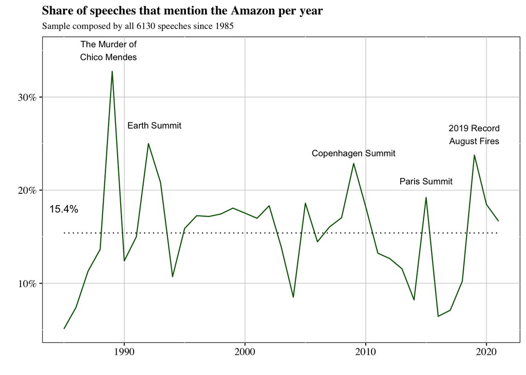

Amazonian speeches in time

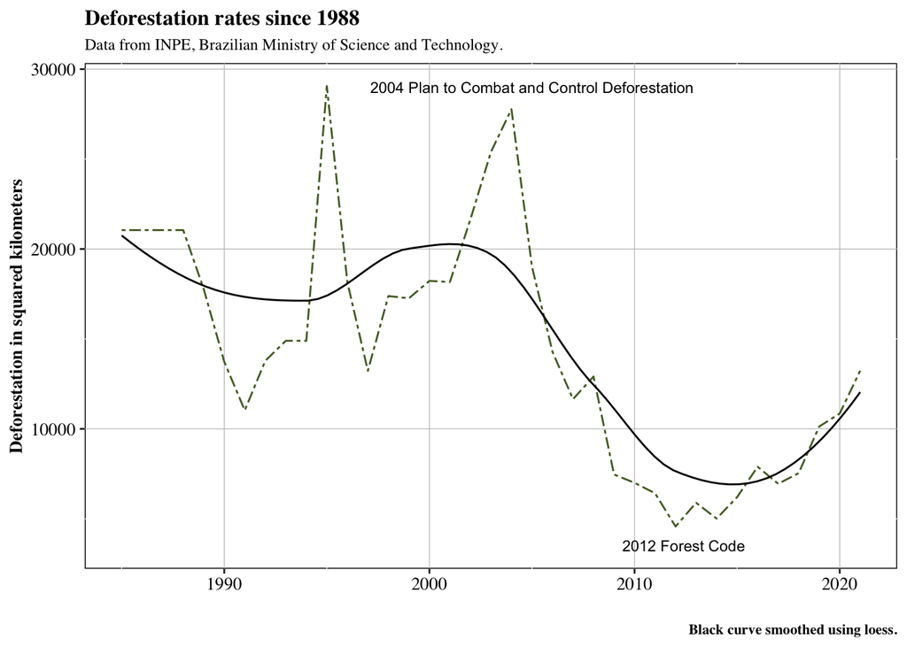

Deforestation rates since 1988

We subsequently observe a steady increase from 6% in 2016 to 24% in 2019, the first year of Bolsonaro’s presidency. At the time, international and national media brought unprecedented attention to Brazilian environmental issues as the record burning of the Amazon led up to a red sky afternoon in São Paulo in August 2019. Alongside this, Bolsonaro’s dismantling of environmental governance and the threats to leave the Paris Agreement had strong media attention, and, as a response, the topic became prominent in his speeches. Bolsonaro went on to retrieve Brazil’s hosting status for COP25.

The frequency at which the Amazon appears in domestic and international speeches varies in similar ways as the maxima in the topic frequencies, led by the events discussed above, appear within and outside Brazil (see Figure 7 appendix). We interpret this as evidence that relevant events drive interest and alter how pressing the Amazon as a policy object is perceived both nationally and internationally. This does not mean, though, that when presidents speak about the Amazon, they highlight the same issues.

## 4.2 Problem-constructions in time

Our subsequent analysis of pure-types and mixed-types suggests that governments do not defend a specific view of the Amazon. The same governments construct the Amazon as various pure and mixed type problems, which unravels a less cohesive story than that told by the literature scrutinizing policy cycles.

### Pure-type problem-constructions

We conceptualize four problem-constructions: sovereignty, economic integration, social development, and conservation. Figure 4, below, illustrates the share of each pure-type in time. Pure problem-constructions dominate, with an average of 56% of all Amazonian statements across time.We identify a discursive shift in problem-constructions from developing the Amazon economically, to conserving it and providing services to its citizens. Pure economic integration constructions dominated constructions from 1985 to the late 2000s. This is especially pertinent during the Cardoso administration. Brazilian presidents after Cardoso moved from employing one problem-constructions consistently to a more diverse strategy. During Lula’s terms in office, constructing the Amazon purely as an issue of economic integration decreased, while constructing the Amazon issues of environmental conservation and social development increased. Conservation and social development constructions surpassed economic integration around 2010 and continued to dominate as Amazonian constructions during Rousseff’s administration. Still, environmental conservation and social development problem-constructions were not as dominant in terms of frequency or time in discourses as economic integration was until the early 2000s. Finally, we observe a steady increase in sovereignty constructions in the late 2000s, reaching the highest frequencies with the presidencies of Bolsonaro.

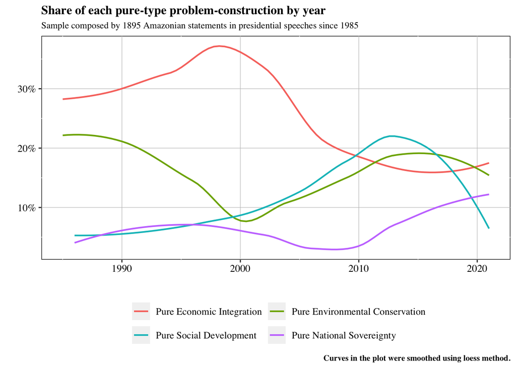

Pure-types in time

### Mixed-type problem-constructions

In a speech, presidents might mix multiple problem-constructions within a same statement about the Amazon. Although presidents prefer pure problem-constructions, they also construct the Amazon as a multifaceted issue. Mixed-type problem-constructions in discourse offer more intricate understandings of the Amazon as a problem. Constructing the Amazon as multiple issues averages at 18% of all constructions in time. Some mixed-types rarely appear so we focus our discussion on those mixed-types with higher incidence. Figure 5, below, displays the averages of mixed-types constructions by presidents.

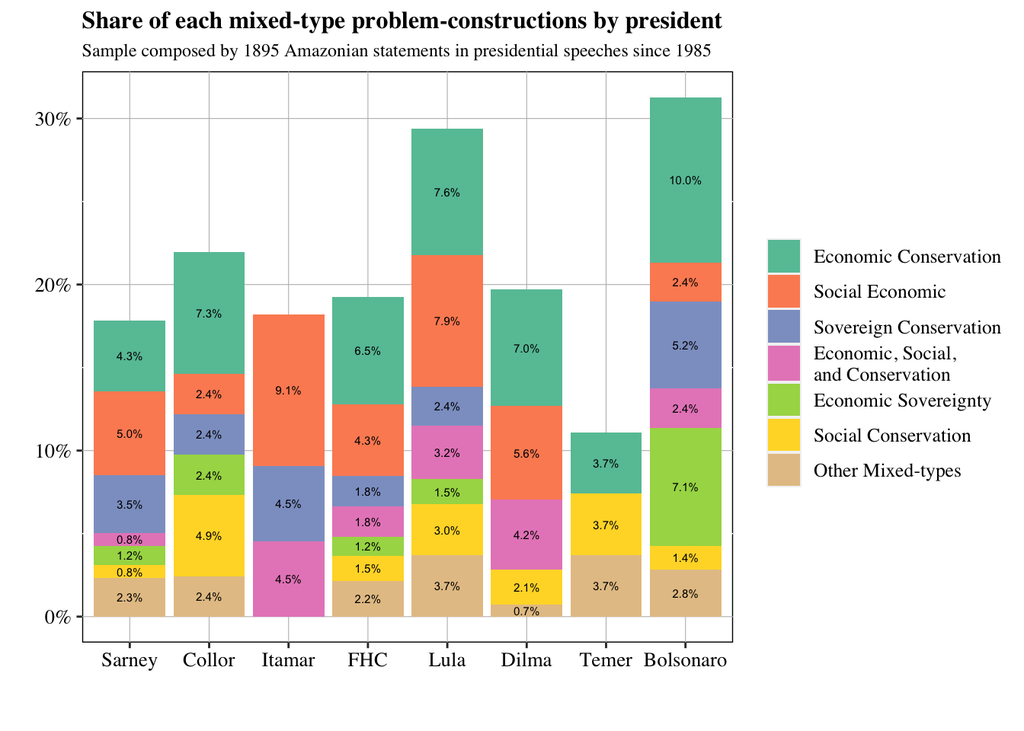

Mixed-types by president

The most frequent mixed-type problem construction of the Amazon is economic conservation. This mixed-type construction, composed of Amazonian statements that construct the Amazon as a problem of both economic integration and environmental conservation, generally increased over time. This increase suggests that later presidents, along with being more diverse in how they construct the Amazon as an issue (see Figure 4), increasingly find ways to reconcile the dictum between the economy and the environment that had prevailed in the previous years. The second most common mixed-type mixes social development and economic integration and appears, on average, in 5.4% of all statements. This is not surprising, as developing countries like Brazil repeatedly claim a “right to develop”, when it comes to negotiating strong climate commitments and policies with a focus on both social development and economic integration. Nonetheless, there is a general increase of mixed-types over time, which is expected given the rise of global agendas understanding interconnections of social, environmental, and economic domains such as the Millennium Development Goals and the Sustainable Development Goals.

Both Lula and Bolsonaro construct the Amazon as a multifaceted issue more frequently than other presidents. Lula usually mixed economic integration with environmental conservation and social development when constructing the Amazon as an issue, while Bolsonaro constructs the Amazon as an issue of national sovereignty and economic integration much more than any other president, mimicking the military dictatorship discourses and policies toward the region (Hecht and Cockburn 1990).

## 4.3 The Amazonian multi-level game: boasting policy outside and talking to people inside

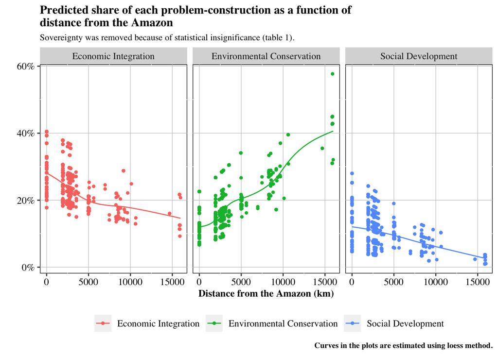

Logistic Regression predicted values

# 5 Discussion and Conclusion

Discursive problem-construction within democracies legitimizes ways of thinking and acting towards the environment. If presidents promote an agenda of economic and social development within Brazil that diverges from the one promoted outside of Brazil, to what extent does the implemented agenda respond to domestic versus international demands? The Brazilian government successfully funded domestic public policy with transnational support on several occasions: the 1992 Pilot Programme of the G7 for the Protection of Rainforest; the 2001 Amazon Regional Protected Areas Program by the World Bank and others; and the 2008 Amazon Fund which provided over USD 1 billion (Silva-Muller and Faul 2022). Concurrently, the national agenda of economic integration or social development was pursued. For instance, rural credit offered to local agricultural producers in Amazonian states, went up from 500 million reais a year in 1999 to over 4 billion a year by 2012 (Capobianco 2021). Multiple contradictory policies negotiated simultaneously, imply that presidents construct policy objects as issues important to local electorates within the Amazon while, at the same time, highlighting aspects important for international actors elsewhere.

The decrease in deforestation that took place in Brazil from 2004 to 2012, was accompanied by a period of strong economic growth. With the strengthening of environmentalism, through the participation of indigenous and civil society in politics (Hochstetler and Keck 2007), the fall of economic integration problem-construction and the rise of both social development and environmental conservation constructions in the 2000s suggest a new balance between granting local livelihoods their rights and economic development. This new balance was both unprecedented and not long-standing. Unprecedented because never before the environment and people were equally present as the economy in presidential discourse. Not long-standing because the dismantling of environmental policy in favor of infrastructure and agricultural expansion was already on its way in the late 2010s. The 2012 New Forest Code is seen as a turning point: political opposition to conservation organized itself and managed to lobby with the executive and won these battles even though they were largely opposed by environmentalists.

The steady increase of sovereignty problem-constructions starting in 2010 brings an eerie twist. As we conceptualize and operationalize sovereignty as containing internal and external perceived threats to the Amazon, we interpret this increase as not only attacks on international interference in the Amazon but also on indigenous and traditional populations. The embryo of Bolsonaro’s Amazonian discourse was breeding half a decade before he took office. Bolsonaro is a product of political re-organization of national and international actors - to which Rousseff and Temer were already responding in discourse - rather than the cause of change in politics. The political forces in Brazilian democracy that drove these policy and discursive changes in problem-construction were long in the making, Bolsonaro’s problem-constructions and policies are the strongest forms of this shift.

# Acknowledgements

The authors are extremely grateful to Graziella Moraes Silva and James Hollway for their support. The authors would also like to thank Matias, Federico, Rodrigo, and Anna for valuable comments on earlier drafts of this paper.

# Disclosure Statement

The authors report there are no competing interests to declare.

# References

Acker, Antoine. 2021. “Amazon Development,” Oxford research encyclopedia of latin american history.,. https://doi.org/10.1093/acrefore/9780199366439.013.837.

Alesina, Alberto F., and Paola Giuliano. 2009. “Preferences for Redistribution.” https://www.nber.org/papers/w14825.

Andonova, Liliana B. 2014. “Boomerangs to Partnerships? Explaining State Participation in Transnational Partnerships for Sustainability.” *Comparative Political Studies* 47 (3): 481–515. https://doi.org/10.1177/0010414013509579.

Assunção, Juliano, Clarissa Gandour, and Rudi Rocha. 2015. “Deforestation Slowdown in the Brazilian Amazon: Prices or Policies?” *Environment and Development Economics* 20 (6): 697–722. https://doi.org/10.1017/S1355770X15000078.

Bacchi, Carol Lee. 2009. *Analysing Policy: What’s the Problem Represented to Be?* Pearson.

Barros, Antonio Teixeira de. 2020. “Discursos parlamentares sobre a Amazônia: sobre o que falam os deputados brasileiros.” *Política & Sociedade* 19 (46): 299–331. https://doi.org/10.5007/2175-7984.2020.e66962.

Becker, Bertha K. 2005. “Geopolítica da Amazônia.” *Estudos Avançados* 19 (April): 71–86. https://doi.org/10.1590/S0103-40142005000100005.

Bevitori, Cinzia. 2015. “Discursive Constructions of the Environment in American Presidential Speeches 19602013: A Diachronic Corpus-Assisted Study.” *Corpora and Discourse Studies*, 110–33. https://doi.org/10.1057/9781137431738_6.

Brice, and Smith. 2021. “The Amazon Is Fast Approaching a Point of No Return.” *Bloomberg.com*, July. https://www.bloomberg.com/news/features/2021-07-29/amazon-rainforest-deforestation-land-grabs-surge-under-bolsonaro-in-brazil.

Calderwood, Kevin J. 2020. “Going Global: Climate Change Discourse in Presidential Communications.” *Environmental Communication* 14 (1): 52–67. https://doi.org/10.1080/17524032.2019.1592005.

Campbell, Jeremy M. 2015. *Conjuring Property: Speculation and Environmental Futures in the Brazilian Amazon*. Illustrated edition. Seattle: University of Washington Press.

Capobianco, João Paulo. 2019. “Avances y retrocesos de la sostenibilidad en la Amazonia: un análisis de la gobernanza socioambiental en la Amazonia,” January. https://gredos.usal.es/handle/10366/139311.

———. 2021. *Amazônia: Uma Década de Esperança*. 1ª edição. São Paulo: Estação Liberdade.

Cezar, Rodrigo Fagundes. 2020. “Brazilian Presidential Speeches from 1985 to July 2020.” https://dataverse.harvard.edu/dataset.xhtml?persistentId=doi:10.7910/DVN/M9UU09.

Da Silva, Antonio José Bacelar, and Erika Robb Larkins. 2019. “The Bolsonaro Election, Antiblackness, and Changing Race Relations in Brazil.” *The Journal of Latin American and Caribbean Anthropology* 24 (4): 893–913.

Franchini, Matias Alejandro, and Eduardo Viola. 2019. “Myths and Images in Global Climate Governance, Conceptualization and the Case of Brazil (1989 - 2019).” *Revista Brasileira de Política Internacional* 62 (September). https://doi.org/10.1590/0034-7329201900205.

Gillion, Daniel Q. 2016. *Governing with Words: The Political Dialogue on Race, Public Policy, and Inequality in America*. Cambridge: Cambridge University Press. https://doi.org/10.1017/CBO9781316412299.

Grimmer, Justin, Margaret E. Roberts, and Brandon M. Stewart. 2022. *Text as Data: A New Framework for Machine Learning and the Social Sciences*. Princeton, New Jersey Oxford: Princeton University Press.

Harris, Bryan. 2021. “Drought Puts Amazon at Risk of ‘Large-Scale Dieback’, Researchers Warn.” *Financial Times*, July. https://www.ft.com/content/02071ae7-dcf5-4c61-9c3c-b55f5aef8b0e.

Hecht, Susanna B., and Alexander Cockburn. 1990. *The Fate of the Forest: Developers, Destroyers, and Defenders of the Amazon, Updated Edition*. Chicago, IL: University of Chicago Press. https://press.uchicago.edu/ucp/books/book/chicago/F/bo10387801.html.

Hirschman, Albert O. 1963. *Journeys Toward Progress: Studies of Economic Policy-Making in Latin America*. Twentieth Century Fund.

Hochstetler, Kathryn. 2021. “Climate Institutions in Brazil: Three Decades of Building and Dismantling Climate Capacity.” *Environmental Politics* 30 (sup1): 49–70. https://doi.org/10.1080/09644016.2021.1957614.

Hochstetler, Kathryn, and Margaret E. Keck. 2007. *Greening Brazil: Environmental Activism in State and Society*. https://doi.org/10.1215/9780822390596.

Keck, Margaret E., and Kathryn Sikkink. 1998. *Activists Beyond Borders: Advocacy Networks in International Politics*. 1st Edition. Ithaca, N.Y: Cornell University Press.

López, Matias, Graziella Moraes Silva, Chana Teeger, and Pedro Marques. 2020. “Economic and Cultural Determinants of Elite Attitudes Toward Redistribution.” *Socio-Economic Review*, May. https://doi.org/10.1093/ser/mwaa015.

Meyer, David, Evgenia Dimitriadou, Kurt Hornik, Andreas Weingessel, and Friedrich Leisch. 2021. *E1071: Misc Functions of the Department of Statistics, Probability Theory Group (Formerly: E1071), TU Wien*. https://CRAN.R-project.org/package=e1071.

Miranda, David. 2021. “Bolsonaro’s 1,000km Amazon Railway Will Cause Climate Chaos. It Must Be Stopped.” *The Guardian*, July. https://www.theguardian.com/commentisfree/2021/jul/28/bolsonaro-amazon-railway-climate-chaos-must-be-stopped.

Noble, William S. 2006. “What Is a Support Vector Machine?” *Nature Biotechnology* 24 (12): 1565–67.

Pádua, José Augusto. 2012. “Environmentalism in Brazil: A Historical Perspective.” *A Companion to Global Environmental History* 1: 455–73.

Pereira, Joana Castro, and Eduardo Viola. 2021. *Climate Change and Biodiversity Governance in the Amazon: At the Edge of Ecological Collapse?* Routledge.

Putnam, Robert D. 1988. “Diplomacy and Domestic Politics: The Logic of Two-Level Games.” *International Organization* 42 (3): 427–60. http://www.jstor.org/stable/2706785.

Silva-Muller, Livio. 2022. “Payment for Ecosystem Services and the Practices of Environmental Fieldworkers in Policy Implementation: The Case of Bolsa Floresta in the Brazilian Amazon.” *Land Use Policy* 120 (September): 106251. https://doi.org/10.1016/j.landusepol.2022.106251.

Silva-Muller, Livio, and Moira V. Faul. 2022. “Protecting the Amazon and Its People: The Role of Civil Society in Local Effectiveness of Trasnational Partnerships.” In *Partnerships for Sustainability in Contemporary Global Governance*, 83–103. Routledge. https://doi.org/10.4324/9781003148371-6.

Soares-Filho, Britaldo, Raoni Rajão, Marcia Macedo, Arnaldo Carneiro, William Costa, Michael Coe, Hermann Rodrigues, and Ane Alencar. 2014. “Cracking Brazil’s Forest Code.” *Science* 344 (6182): 363–64. https://doi.org/10.1126/science.1246663.

Sposito, Henrique. 2021. *Poldis: Tools for Analyzing Political Discourse*. https://github.com/henriquesposito/poldis.

Viola, Eduardo J. 1987. “O Movimento Ecológico No Brasil, 1974-1986: Do Ambientalismo à Ecopolítica.” *Revista Brasileira de Ciencias Sociais* 3 (93): 5–26. http://anpocs.com/images/stories/RBCS/03/rbcs03_01.pdf.

Waroux, Yann de, Rachael D. Garrett, Mollie Chapman, Cecilie Friis, Jeffrey Hoelle, Leonie Hodel, Kelly Hopping, and Julie Gwendolin Zaehringer. 2021. “The Role of Culture in Land System Science.” *Journal of Land Use Science* 16 (4): 450–66. https://doi.org/10.1080/1747423X.2021.1950229.

Zarefsky, David. 2004. “Presidential Rhetoric and the Power of Definition.” *Presidential Studies Quarterly* 34 (3): 607–19. https://www.jstor.org/stable/27552615.

# Appendix

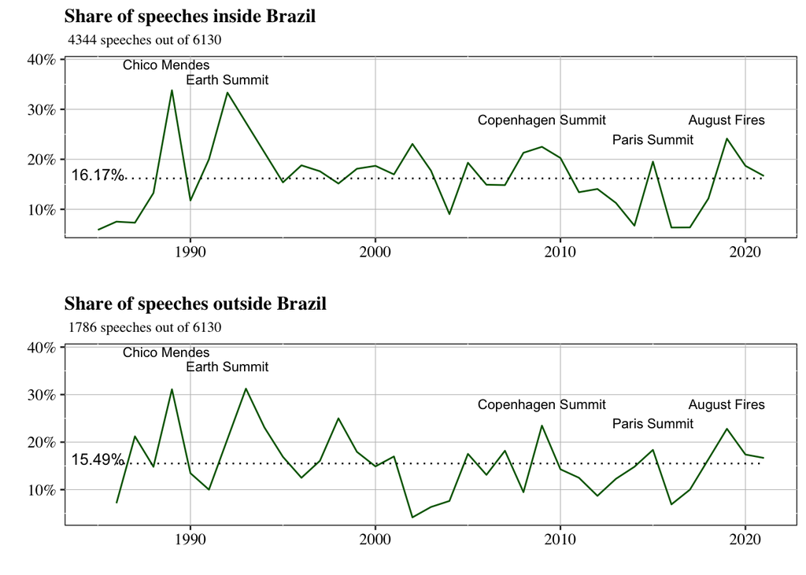

Amazonian speeches in time and space

[^1]: Both co-authors contributed equally to the article. Names are ordered alphabetically. Livio is a PhD Candidate in Anthropology and Sociology at the Geneva Graduate Institute and affiliated to the Albert Hirschman Centre on Democracy. Henrique is a PhD Candidate in International Relations and Political Sciences at the Geneva Graduate Institute and affiliated to the Centre for International Environmental Studies.
[^2]: We use the noun transnationalism, the adverb transnationally, and the adjective transnational interchangeably
[^3]: For comparison purposes the averages for other policy objects in the same corpus of speeches are: Inequality (14.7%), Criminality (17.3%), Inflation (20.9%), and Unemployment (13.8%).